```python
#!/usr/bin/python
#-*- coding: UTF-8 -*-
```

# kNN分类算法

计算测试点到已标记数据集各点的距离，  
选择距离最近的k个已标记点进行举手表决，  
以出现频次最高的标记作为测试点的预测标记

优点：精度高、对异常值不敏感、无数据输入假定  
缺点：计算复杂度高、空间复杂度高  
适用数据范围：数值型、标称型

## 效果演示

```python
import kNN
```

### 获取数据集

```python
group, label = kNN.createDataSet()
```

```python
group
```

```
array([[ 1. ,  1.1],
       [ 1. ,  1. ],
       [ 0. ,  0. ],
       [ 0. ,  0.1]])
```

```python
label
```

```
['A', 'A', 'B', 'B']
```

### 分类

```python
kNN.classify0(inX = [0,0], dataSet = group, labels = label, k = 3)
```

```
'B'
```

## classify0函数

```python
from numpy import *
import operator
from os import listdir
```

### 输入参数

```python
# 测试数据
inX = [0, 0]
# 用于分类的数据集和标记
dataSet = group
labels = label
# k参数
k = 3
```

### 计算测试点到数据集各点的距离

差值、平方、求和、开根

```python
# 获取数据集的行数
print(dataSet.shape)
dataSetSize = dataSet.shape[0]
```

```
(4L, 2L)
```

#### np.tile函数说明

tile(A, reps)  
按reps指定的大小扩展A数组

- A为一个np.array
- reps可以是单独一个数，也可以是一个元组
- tile将把A作为基本元素，按照reps指定的大小构造数组
- 举例：(a = np.array([[1,2], [3,4]]))
  - np.tile(a, 2)  
    Output: array([[1,2,1,2], [3,4,3,4]]) -> 2x4
  - np.tile(a, (2,1))  
    Output: array([[1,2], [3,4], [1,2], [3,4]]) -> 4x2

```python
# 计算测试点到数据集各点在x、y轴上的差值
print("tile: ", tile(inX, (dataSetSize, 1)) )
print("dataSet: ", dataSet)
diffMat = tile(inX, (dataSetSize, 1)) - dataSet
print("diffMat: ", diffMat)
```

```
('tile: ', array([[0, 0],
       [0, 0],
       [0, 0],
       [0, 0]]))
('dataSet: ', array([[ 1. ,  1.1],
       [ 1. ,  1. ],
       [ 0. ,  0. ],
       [ 0. ,  0.1]]))
('diffMat: ', array([[-1. , -1.1],
       [-1. , -1. ],
       [ 0. ,  0. ],
       [ 0. , -0.1]]))
```

```python
# 平方：各元素分别平方
sqDiffMat = diffMat**2
# 求和：对第一维度求和
# 行是第零维度，列是第一维度
sqDistances = sqDiffMat.sum(axis=1)
# 开根
distances = sqDistances**0.5
```

#### np.argsort函数

a.argsort(axis = -1, kind = 'quicksort', order = None)  
返回np.array的排序结果，这个结果以元素索引号的形式呈现（返回值类型为np.array）

```python
# 获取距离的排序（argsort函数返回排序结果，但返回值为索引号）
sortedDistIndicies = distances.argsort()

print("distances: ", distances)
print("sortedDistIndicies: ", sortedDistIndicies)
```

```
('distances: ', array([ 1.48660687,  1.41421356,  0.        ,  0.1       ]))
('sortedDistIndicies: ', array([2, 3, 1, 0], dtype=int64))
```

### 统计距离最近的前k个数据集中标记出现的频次（k=3）

```python
# 记录的字典
classCount = {}
# 统计前k个数据的标记出现频次
for i in range(k):
    # 获取第i个数据的标记
    voteIlabel = labels[sortedDistIndicies[i]]
    # 计数
    classCount[voteIlabel] = classCount.get(voteIlabel, 0) + 1

    print("i:%d, distance:%f, voteIlabel:%s" % (i, distances[sortedDistIndicies[i]], voteIlabel))
print("classCount", classCount)
```

```
i:0, distance:0.000000, voteIlabel:B
i:1, distance:0.100000, voteIlabel:B
i:2, distance:1.414214, voteIlabel:A
('classCount', {'A': 1, 'B': 2})
```

```python
print("classCount.items(): ", classCount.items())
# 字典不可排序，需要转化为序列或迭代器
# 排序关键字：字典的值，也就是转化后的序列的第一项元素
# 反向：从高到低排序
sortedClassCount = sorted(classCount.iteritems(), key=operator.itemgetter(1), reverse=True)
print("sortedClassCount: ", sortedClassCount)
```

```
('classCount.items(): ', [('A', 1), ('B', 2)])
('sortedClassCount: ', [('B', 2), ('A', 1)])
```

### 取得频次最大者作为预测的分类结果

```python
sortedClassCount[0][0]
```

```
'B'
```

# 使用Matplotlib绘制散点图

```python
import kNN, matplotlib
import matplotlib.pyplot as plt
from numpy import *
```

```python
datingDataMat, datingLabels = kNN.file2matrix('datingTestSet2.txt')

print("datingDataMat: ", datingDataMat)
print("datingLables[:20]: ", datingLabels[:20])
print("datingDataMat.shape: ", datingDataMat.shape)
print("len(datingLabels)", len(datingLabels))
```

```
('datingDataMat: ', array([[  4.09200000e+04,   8.32697600e+00,   9.53952000e-01],
       [  1.44880000e+04,   7.15346900e+00,   1.67390400e+00],
       [  2.60520000e+04,   1.44187100e+00,   8.05124000e-01],
       ...,
       [  2.65750000e+04,   1.06501020e+01,   8.66627000e-01],
       [  4.81110000e+04,   9.13452800e+00,   7.28045000e-01],
       [  4.37570000e+04,   7.88260100e+00,   1.33244600e+00]]))
('datingLables[:20]: ', [3, 2, 1, 1, 1, 1, 3, 3, 1, 3, 1, 1, 2, 1, 1, 1, 1, 1, 2, 3])
('datingDataMat.shape: ', (1000L, 3L))
('len(datingLabels)', 1000)
```

## 用plt画散点图

创建图、添加子图、为子图添加数据和样式、显示图

### 第0列和第1列数据

明显划分出三个区域

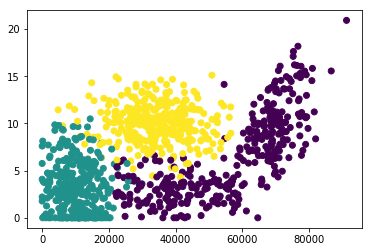

```python
# 创建一张图
fig = plt.figure()
# 添加一张子图，位置在1行1列的第一个位置（也即只有一张子图）
ax = fig.add_subplot(111)   # 等价于fig.subplot(1,1,1)
# 为子图添加数据和样式
ax.scatter(datingDataMat[:,0],         # x轴数据，取矩阵第0列
           datingDataMat[:,1],         # y轴数据，取矩阵第1列
           c = array(datingLabels))    # 根据标记的数值设置数据颜色
plt.show()
```

### 第1列和第2列数据

区域重叠，划分不明显

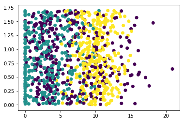

```python
# 创建一张图
fig = plt.figure()
# 添加一张子图，位置在1行1列的第一个位置（也即只有一张子图）
ax = fig.add_subplot(111)   # 等价于fig.subplot(1,1,1)
# 为子图添加数据和样式
ax.scatter(datingDataMat[:,1],         # x轴数据，取矩阵第1列
           datingDataMat[:,2],         # y轴数据，取矩阵第2列
           c = array(datingLabels))    # 根据标记的数值设置数据颜色
plt.show()
```

### 第0列和第2列数据

有一定的区域划分，但重叠区域还是很多

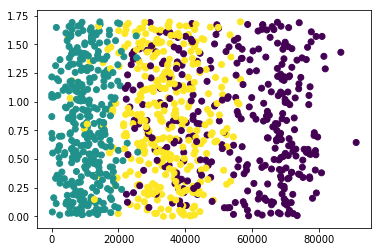

```python
# 创建一张图
fig = plt.figure()
# 添加一张子图，位置在1行1列的第一个位置（也即只有一张子图）
ax = fig.add_subplot(111)   # 等价于fig.subplot(1,1,1)
# 为子图添加数据和样式
ax.scatter(datingDataMat[:,0],         # x轴数据，取矩阵第0列
           datingDataMat[:,2],         # y轴数据，取矩阵第2列
           c = array(datingLabels))    # 根据标记的数值设置数据颜色
plt.show()
```

# 数据归一化处理

newVal = ( oldVal - minVal ) / ( maxVal - minVal )

```python
import kNN
from numpy import *
```

```python
datingDataMat, datingLabels = kNN.file2matrix('datingTestSet2.txt')

print("datingDataMat: ", datingDataMat)
print("datingLables[:20]: ", datingLabels[:20])
print("datingDataMat.shape: ", datingDataMat.shape)
print("len(datingLabels)", len(datingLabels))
```

```
('datingDataMat: ', array([[  4.09200000e+04,   8.32697600e+00,   9.53952000e-01],
       [  1.44880000e+04,   7.15346900e+00,   1.67390400e+00],
       [  2.60520000e+04,   1.44187100e+00,   8.05124000e-01],
       ...,
       [  2.65750000e+04,   1.06501020e+01,   8.66627000e-01],
       [  4.81110000e+04,   9.13452800e+00,   7.28045000e-01],
       [  4.37570000e+04,   7.88260100e+00,   1.33244600e+00]]))
('datingLables[:20]: ', [3, 2, 1, 1, 1, 1, 3, 3, 1, 3, 1, 1, 2, 1, 1, 1, 1, 1, 2, 3])
('datingDataMat.shape: ', (1000L, 3L))
('len(datingLabels)', 1000)
```

```python
dataSet = datingDataMat
```

```python
# 获取各列的最大最小值
# 即取得行即第零维的最大最小值
# 如果不指明维度，则表示取所有元素中的最大最小值
minVals = dataSet.min(0)
maxVals = dataSet.max(0)

print("minVals: ", minVals)
print("maxVals: ", maxVals)
```

```
('minVals: ', array([ 0.      ,  0.      ,  0.001156]))
('maxVals: ', array([  9.12730000e+04,   2.09193490e+01,   1.69551700e+00]))
```

```python
# 获取数据行数
m = dataSet.shape[0]
# 将（最大值 - 最小值） 和 最小值 向量扩展为m行
diffSet = tile( maxVals - minVals, (m, 1) )
minSet  = tile( minVals, (m, 1) )
# 归一化
normDataSet = ( dataSet - minSet ) / diffSet
```

```python
normDataSet
```

```
array([[ 0.44832535,  0.39805139,  0.56233353],
       [ 0.15873259,  0.34195467,  0.98724416],
       [ 0.28542943,  0.06892523,  0.47449629],
       ...,
       [ 0.29115949,  0.50910294,  0.51079493],
       [ 0.52711097,  0.43665451,  0.4290048 ],
       [ 0.47940793,  0.3768091 ,  0.78571804]])
```